# GroupI_HM1

Flego, Gigante, Norbedo, Ortoleva, Mutua

2026-10-31

## FSDS - Chapter 2

### Ex 2.8 (Nicola Gigante)

Each time a person shops at a grocery store, the event of catching a cold or some other virus from another shopper is independent from visit to visit and has a constant probability over the year, equal to 0.01.

1. In 100 trips to this store over the course of a year, the probability of catching a virus while shopping there is 100(0.01) = 1.0. What is wrong with this reasoning?
2. Find the correct probability in (a).

**Solution**

#### (a)

The formula at point (a) is the formula for the expected value of a Binomial distribution ($\mathbb{E}(X) = np$). Summing the event probabilities is allowed only if the events are mutually exclusive, but in this case they are independent. Furthermore, if we visited the store 150 times, the probability would be 1.5, which is impossible.

#### (b)

The actual probability, for 100 independent events with constant probability, is
$$P(X \ge 1) = P(X = 1) +
\dots + P(X = 100)$$
Since it is too long to compute directly, we can simply compute
$$P(X \ge 1) = 1 - P(X =
0)$$
that is to say, 1 minus the probability of never catching a virus. The probability of catching the virus in one visit is $p = 0.01$, so the probability of not catching it in one visit is $1 - p = 0.99$. Since we are dealing with independent events, the probability of not catching the virus in all 100 visits is simply:
$$P(X = 0) = (1 - p)^{100} =
(0.99)^{100}$$

```r
n <- 100
p <- 0.01
p_0 <- (1 - p)**n
p_ge1 <- 1 - p_0
p_ge1
```

```
## [1] 0.6339677
```

Finally, the probability of catching the virus at least once in 100 visits is:
$$P(X \ge 1) = 1 - P(X = 0) = 1 -
(0.99)^{100} \approx 0.634$$

### Ex 2.16 (Fadhla Mohamed Mutua)

Each day a hospital records the number of people who come to the emergency room for treatment.

1. In the first week, the observations from Sunday to Saturday are 10, 8, 14, 7, 21, 44, 60. Do you think that the Poisson distribution might describe the random variability of this phenomenon adequately? Why or why not?
2. Would you expect the Poisson distribution to better describe, or more poorly describe, the number of weekly admissions to the hospital for a rare disease? Why?

**Solution**

#### (a)

No. A Poisson distribution has a single constant rate $\lambda$, with
$$E[X] = \operatorname{Var}(X) = \lambda$$
so the variance-to-mean ratio should be close to 1.

```r
x <- c(10, 8, 14, 7, 21, 44, 60)
mean(x)
```

```
## [1] 23.42857
```

```r
var(x)
```

```
## [1] 423.9524
```

```r
var(x) / mean(x)
```

```
## [1] 18.09553
```

The variance is about 18 times the mean so the rate is not constant.

#### (b)

Better. For a rare disease in a very large population, each person has a small probability $p$ of being admitted, so the weekly count is $\text{Bin}(n, p)$. For $n$ large and $p$ small, this is approximately $\text{Pois}(np)$, provided the cases are independent and the rate is roughly constant. If the disease is contagious, cases cluster, independence fails and the variance exceeds the mean.

```r
set.seed(42)
n <- 1000
lam <- 3

ind <- rbinom(n, size = 1e6, prob = lam / 1e6)

# Clustered cases: Poisson(1) primary cases per week, each bringing Poisson(2) linked cases.
# The mean is still 3, but admissions arrive in clumps.
clu <- replicate(n, {
  k <- rpois(1, 1)
  sum(1 + rpois(k, 2))
})

dis <- function(y) var(y) / mean(y)
round(c(independent = dis(ind), clustered = dis(clu)), 2)
```

```
## independent   clustered
##        1.00        3.84
```

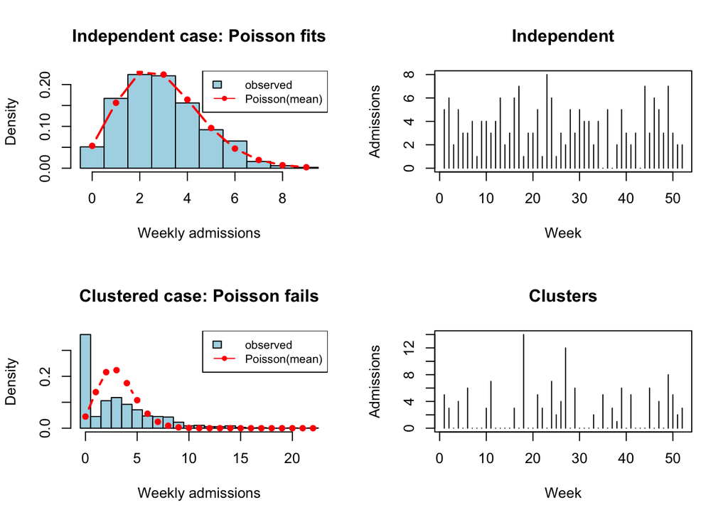

```r
show <- function(y, main) {
  m <- max(y)
  hist(y,
    breaks = seq(-0.5, m + 0.5, 1), freq = FALSE, col = "lightblue",
    main = main, xlab = "Weekly admissions"
  )
  points(0:m, dpois(0:m, mean(y)), type = "b", col = "red", pch = 16, lwd = 2)
  legend("topright", c("observed", "Poisson(mean)"),
    fill = c("lightblue", NA), border = c("black", NA),
    col = c(NA, "red"), lty = c(NA, 1), pch = c(NA, 16), cex = 0.8
  )
}

par(mfrow = c(2, 2))
show(ind, "Independent case: Poisson fits")
plot(ind[1:52], type = "h", xlab = "Week", ylab = "Admissions", main = "Independent")
show(clu, "Clustered case: Poisson fails")
plot(clu[1:52], type = "h", xlab = "Week", ylab = "Admissions", main = "Clusters")
```

### Ex 2.21 (Alessio Flego)

Plot the gamma distribution by fixing the shape parameter $k = 3$ and setting the scale parameter $= 0.5, 1, 2, 3, 4, 5$. What is the effect of increasing the scale parameter? (See also Exercise 2.48.)

**Solution**

The gamma pdf (2.10) is
$$f(y; k, \lambda)
= \frac{\lambda^k}{\Gamma(k)} e^{-\lambda y} y^{k-1}, \qquad y \ge
0$$
where $k$ is the shape parameter and $\theta = 1/\lambda$ is the scale parameter. Written in terms of $\theta$,
$$f(y;
k, \theta) = \frac{1}{\Gamma(k)\,\theta^k}\, y^{k-1} e^{-y/\theta},
\qquad y \ge 0$$
and, from (2.11),
$$\mu = k\theta, \qquad \sigma = \sqrt{k}\,\theta,
\qquad \text{mode} = (k-1)\theta \quad (k > 1)$$

In R, `dgamma(y, shape, scale)` uses exactly this parametrization.

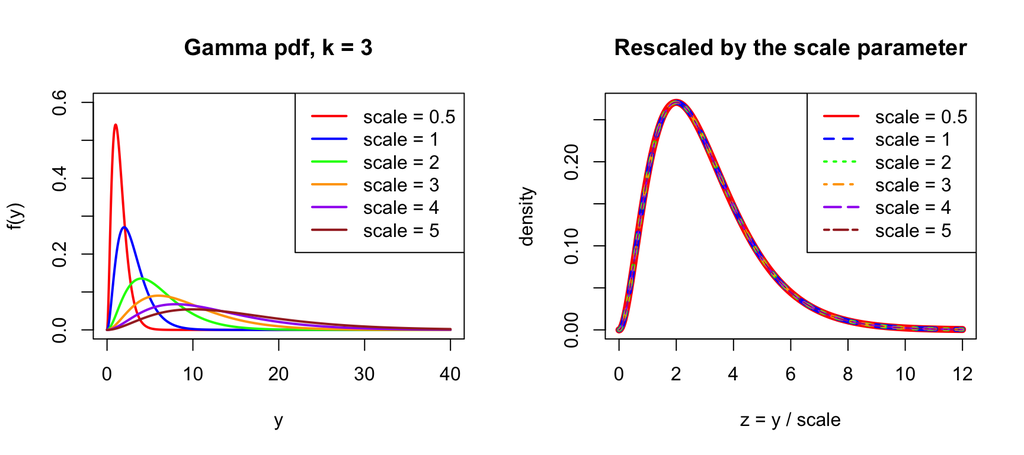

```r
k <- 3
theta <- c(0.5, 1, 2, 3, 4, 5)
cols <- c("red", "blue", "green", "orange", "purple", "brown")

par(mfrow = c(1, 2))

# pdfs on the original scale
curve(dgamma(x, shape = k, scale = theta[1]), 0, 40,
  n = 1000, col = cols[1], lwd = 2, ylim = c(0, 0.6),
  xlab = "y", ylab = "f(y)", main = "Gamma pdf, k = 3"
)
for (i in 2:6) curve(dgamma(x, shape = k, scale = theta[i]), add = TRUE, n = 1000, col = cols[i], lwd = 2)
legend("topright", legend = paste("scale =", theta), col = cols, lwd = 2)

# pdfs of Z = Y / theta: f_Z(z) = theta * f_Y(theta * z)
z <- seq(0, 12, length.out = 500)
plot(z, theta[1] * dgamma(theta[1] * z, shape = k, scale = theta[1]),
  type = "l", col = cols[1], lwd = 6,
  xlab = "z = y / scale", ylab = "density", main = "Rescaled by the scale parameter"
)
for (i in 2:6) lines(z, theta[i] * dgamma(theta[i] * z, shape = k, scale = theta[i]), col = cols[i], lwd = 6 - 0.9 * i, lty = i)
legend("topright", legend = paste("scale =", theta), col = cols, lwd = 2, lty = 1:6)
```

```r
data.frame(
  scale = theta,
  mean = k * theta,
  sd = round(sqrt(k) * theta, 3),
  mode = (k - 1) * theta,
  max_density = round(dgamma((k - 1) * theta, shape = k, scale = theta), 3)
)
```

```
##   scale mean    sd mode max_density
## 1   0.5  1.5 0.866    1       0.541
## 2   1.0  3.0 1.732    2       0.271
## 3   2.0  6.0 3.464    4       0.135
## 4   3.0  9.0 5.196    6       0.090
## 5   4.0 12.0 6.928    8       0.068
## 6   5.0 15.0 8.660   10       0.054
```

Increasing the scale parameter (with the shape fixed) **stretches the distribution to the right**:

- the mean $k\theta$, the standard deviation $\sqrt{k}\,\theta$ and the mode $(k-1)\theta$ all grow proportionally to $\theta$, so the distribution moves to the right and becomes more spread out;
- since the total area must remain 1, the peak becomes lower (the maximum density is proportional to $1/\theta$) and the curve flatter;
- the **shape does not change**: the skewness $2/\sqrt{k} = 2/\sqrt{3} \approx 1.15$ is the same for every $\theta$.

The right panel shows why $\theta$ is called a scale parameter (Exercise 2.48): if $Z$ has the gamma distribution with $k = 3$ and $\theta = 1$, then $Y = \theta Z$ has $f_Y(y) = \frac{1}{\theta} f_Z(y/\theta)$. Rescaling each curve by its own $\theta$, all six pdfs coincide, i.e. changing $\theta$ only changes the units of measurement of $Y$.

### Ex 2.26 (Giovanni Norbedo)

Refer to Table 2.4 cross classifying happiness with family income.

1. Find and interpret the correlation using scores (i) (1, 2, 3) for each variable, (ii) (1, 2, 3) for family income and (1, 4, 5) for happiness.
2. Construct the joint distribution that has these marginal distributions and exhibits independence of $X$ and $Y$.

**Solution**

#### (a)

To calculate the correlation $\rho$ between $X$ (family income) and $Y$ (happiness), we use the expected values and variances of $X$ and $Y$:

$$\rho = \frac{E[XY] -
E[X]E[Y]}{\sqrt{Var(X) \cdot Var(Y)}}$$

1. Scores $(1, 2, 3)$ for both $X$ and $Y$

$$\rho \approx 0.1907$$

Weak positive correlation. People with higher family income tend to report slightly higher happiness levels.

2. Scores $(1, 2, 3)$ for $X$ and $(1, 4, 5)$ for $Y$

$$\rho \approx 0.1898$$

The correlation remains almost unchanged.

```r
P <- matrix(
  c(
    0.080, 0.198, 0.079,
    0.043, 0.254, 0.143,
    0.017, 0.105, 0.081
  ),
  nrow = 3, byrow = T
)

get_rho <- function(x, y, P) {
  r <- rowSums(P)
  c <- colSums(P)
  Ex <- sum(r * x)
  Ey <- sum(c * y)
  Ex2 <- sum(r * x^2)
  Ey2 <- sum(c * y^2)
  EXY <- sum(P * outer(x, y))

  (EXY - Ex * Ey) / sqrt((Ex2 - Ex^2) * (Ey2 - Ey^2))
}

rho1 <- get_rho(1:3, 1:3, P)
rho2 <- get_rho(1:3, c(1, 4, 5), P)
round(c(rho1, rho2), 4)
```

```
## [1] 0.1907 0.1898
```

#### (b)

Under independence, $P(X=x, Y=y) = P(X=x) \cdot P(Y=y)$.

Multiplying row totals $(0.357, 0.440, 0.203)$ by column totals $(0.140, 0.557, 0.303)$ gives:

$$P_{ind} = \begin{pmatrix} 0.050 &
0.199 & 0.108 \\ 0.062 & 0.245 & 0.133 \\ 0.028 & 0.113
& 0.062 \end{pmatrix}$$

Summing across each row or column restores the original marginal probabilities.

### Ex 2.52 (Giulio Ortoleva)

The *pdf* $f$ of a $N(\mu, \sigma^2)$ distribution can be derived from the standard normal *pdf* $\phi$ shown in equation (2.9).

**equation (2.9)**
$$\varphi(z) = \frac{1}{\sqrt{2\pi}} e^{-z^2/2},
\quad -\infty < z < +\infty.$$
**equation (2.8)**

$$f(y; \mu, \sigma) = \frac{1}{\sqrt{2
\pi} \sigma} e^{-(y-\mu)^2/2\sigma^2}$$

1. Show that the normal *cdf* $F$ relates to the standard normal *cdf* $\Phi$ by $F(y) = \Phi[\frac{(y - \mu)}{\sigma}]$.
2. From (a), show that $f(y) = (1 / \sigma) \varphi[(y - \mu) / \sigma]$, and show this is equation (2.8).

#### Solution (a)

- The cdf of normal distribution is:

$$\begin{aligned}
F(y) &= \int_{-\infty}^y f(u) \, du = \int_{-\infty}^y
\frac{1}{\sqrt{2\pi}\sigma} e^{-\frac{(u - \mu)^2}{2\sigma^2}} \, du
\end{aligned}$$

Substituting:
$$t = \frac{u -
\mu}{\sigma}$$
Calculating dt:
$$dt =
\frac{1}{\sigma} \, du$$

Explicitating the terms to substitutes:
$$\begin{aligned}
F(y) &= \int_{-\infty}^y \frac{1}{\sqrt{2\pi}}
e^{-\frac{1}{2}\left(\frac{u - \mu}{\sigma}\right)^2} \frac{1}{\sigma}
\, du
\end{aligned}$$
Making the substitution:
$$\begin{aligned}
&= \int_{-\infty}^{\frac{y-\mu}{\sigma}} \frac{1}{\sqrt{2\pi}}
e^{-t^2 / 2} \, dt
\end{aligned}$$
This is exactly:
$$\Phi\left(\frac{y-\mu}{\sigma}\right) =
\int_{-\infty}^{\frac{y-\mu}{\sigma}} \frac{1}{\sqrt{2\pi}} e^{-w^2 / 2}
\, dw$$

Then we have:
$$F(y) =
\Phi\left(\frac{y-\mu}{\sigma}\right)$$

#### Solution (b)

$$\begin{aligned}
\frac{1}{\sigma} \left[ \varphi\left(\frac{y-\mu}{\sigma}\right) \right]
&=\\
&= \frac{1}{\sigma} \left[ \frac{1}{\sqrt{2\pi}}
e^{-\frac{1}{2}\left(\frac{y-\mu}{\sigma}\right)^2} \right] \\
&= \frac{1}{\sqrt{2\pi}\sigma}
e^{-\frac{1}{2}\left(\frac{y-\mu}{\sigma}\right)^2} \\
&= \frac{1}{\sqrt{2\pi}\sigma} e^{-\frac{(y-\mu)^2}{2\sigma^2}}
\end{aligned}$$
Which is exactly equation 2.8

### Ex 2.53 (Nicola Gigante)

If $Y$ is a standard normal random variable, with cdf $\Phi$, what is the probability distribution of $X = \Phi(Y)$? Illustrate by randomly generating a million standard normal random variables, applying the cdf function $\Phi()$ to each, and plotting histograms of the (a) $y$ values, (b) $x$ values.

**Solution**

So $Y \sim \mathcal{N}(0, 1)$, with $\Phi(y) = P(Y \le y)$. Since $\Phi(y)$ returns a probability value, $0 \le \Phi(y) \le 1$ and so $0 \le X \le 1$. In order to understand how $X$ is distributed in this interval, we can try to compute the distribution function of $X$, that is to say
$$F_X(x) = P(X \le x) = P(\Phi(Y) \le x)$$
We want to isolate $Y$ so we apply the inverse function:
$$F_X(x) = P(X \le x) =
P(Y \le \Phi^{-1}(x))$$
By definition $P(Y \le a) = \Phi(a)$ then
$$F_X(x) = \Phi(\Phi^{-1}(x)) = x \sim
\mathcal{U}(0,1)$$

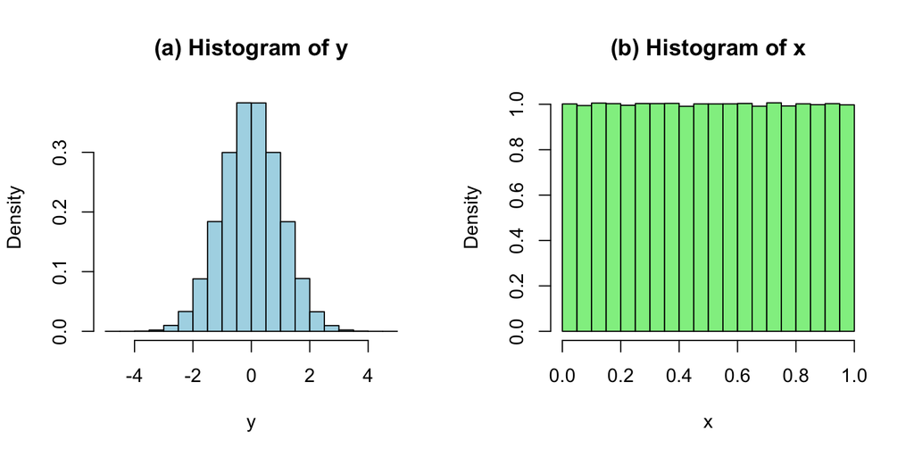

```r
set.seed(123)
y <- rnorm(1000000)
x <- pnorm(y)

par(mfrow = c(1, 2))
hist(y, freq = FALSE, main = "(a) Histogram of y", xlab = "y", col = "lightblue")
hist(x, freq = FALSE, main = "(b) Histogram of x", xlab = "x", col = "lightgreen")
```

#### Comment

We can see that histogram (a) clearly shows a Standard Normal distribution with its typical symmetric bell shape centered at 0, while histogram (b) clearly follows a continuous Uniform distribution on $[0, 1]$ since all bars have a similar height (density close to 1). This empirically confirms our theoretical result that $X = \Phi(Y) \sim \text{Unif}(0, 1)$.

### Ex 2.70 (Fadhla Mohamed Mutua)

The beta distribution is a probability distribution over $(0, 1)$ that is often used in applications for which the random variable is a proportion. The beta pdf is
$$f(y; \alpha, \beta) = \frac{\Gamma(\alpha +
\beta)}{\Gamma(\alpha)\Gamma(\beta)}\,y^{\alpha-1}(1 - y)^{\beta-1},
\qquad 0 \le y \le 1$$
for parameters $\alpha$ and $\beta$, where $\Gamma(\cdot)$ denotes the gamma function.

1. Show that the uniform distribution is the special case $\alpha = \beta = 1$.
2. Show that $\mu = E(Y) = \frac{\alpha}{\alpha + \beta}$.
3. Find $E(Y^2)$. Show that $\operatorname{var}(Y) = \frac{\alpha\beta}{(\alpha + \beta)^2 (\alpha + \beta + 1)} = \frac{\mu(1 - \mu)}{\alpha + \beta + 1}$. For fixed $\alpha + \beta$, note that $\operatorname{var}(Y)$ decreases as $\mu$ approaches 0 or 1.
4. Using a function such as `dbeta` in R, plot the beta pdf for (i) $\alpha = \beta = 0.5, 1.0, 10, 100$, (ii) some values of $\alpha > \beta$ and some values of $\alpha < \beta$. Describe the impact of $\alpha$ and $\beta$ on the shape and spread.

**Solution**

#### (a)

The beta pdf with $\alpha=\beta=1$ is
$$f(y; 1, 1) = \frac{\Gamma(1 +
1)}{\Gamma(1)\Gamma(1)}\,y^{1-1}(1 - y)^{1-1}, \qquad 0 \le y \le
1$$

For a positive integer $n$, $\Gamma(n) = (n-1)!$, so
$$\begin{aligned}
\Gamma(1 + 1) &= \Gamma(2) = 1! = 1 \\
\Gamma(1) &= 0! = 1 \\
y^{1-1} &= y^{0} = 1 \\
(1 - y)^{1-1} &= (1 - y)^{0} = 1
\end{aligned}$$

Thus
$$f(y; 1, 1) = \frac{1!}{0!\,0!}\cdot
1 = 1, \qquad 0 \le y \le 1$$

The uniform pdf on $(a, b)$ with $a = 0$, $b = 1$ is
$$f(y; a, b) = \frac{1}{b-a} = \frac{1}{1-0} = 1,
\qquad 0 \le y \le 1$$

```r
y <- seq(0, 1, length.out = 5)
dbeta(y, 1, 1)
```

```
## [1] 1 1 1 1 1
```

```r
dunif(y, 0, 1)
```

```
## [1] 1 1 1 1 1
```

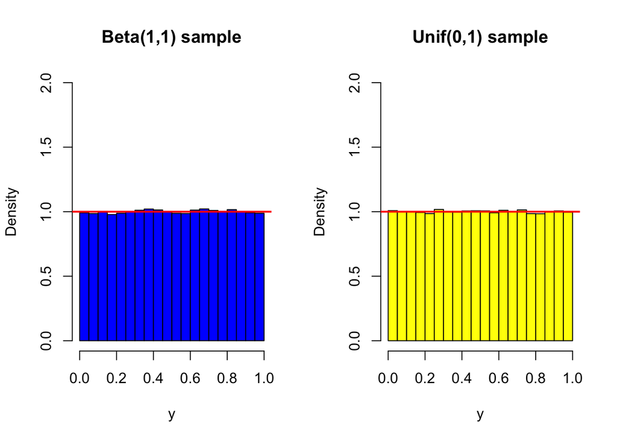

```r
par(mfrow = c(1, 2))

n <- 1e5
hist(rbeta(n, 1, 1),
  freq = FALSE, breaks = 30, col = "blue",
  ylim = c(0, 2), xlab = "y", main = "Beta(1,1) sample"
)
abline(h = 1, col = "red", lwd = 2)
hist(runif(n, 0, 1),
  freq = FALSE, breaks = 30, col = "yellow",
  ylim = c(0, 2), xlab = "y", main = "Unif(0,1) sample"
)
abline(h = 1, col = "red", lwd = 2)
```

#### (b)

The mean is
$$E[Y] = \int_0^1 y\,f(y;
\alpha, \beta)\,dy = \frac{\Gamma(\alpha +
\beta)}{\Gamma(\alpha)\Gamma(\beta)} \int_0^1 y^{\alpha}(1 -
y)^{\beta-1}\,dy$$

Recall the beta and gamma functions
$$B(a,
b) = \int_0^1 x^{a-1}(1-x)^{b-1}\,dx, \qquad \Gamma(z) = \int_0^\infty
t^{z-1}e^{-t}\,dt$$

The product of two gamma functions is
$$\Gamma(a)\Gamma(b) =
\int_0^\infty\!\!\int_0^\infty
u^{a-1}v^{b-1}e^{-(u+v)}\,du\,dv$$

Take $s = u + v \in (0, +\infty)$ and $x = \dfrac{u}{u+v} \in (0, 1)$, so that
$$\begin{cases}
u = xs \\
v = (1-x)s
\end{cases}$$

The change of variables has Jacobian
$$|J|
=
\begin{vmatrix}
\dfrac{\partial u}{\partial x} & \dfrac{\partial u}{\partial s}
\\[6pt]
\dfrac{\partial v}{\partial x} & \dfrac{\partial v}{\partial s}
\end{vmatrix}
= \begin{vmatrix} s & x \\ -s & 1-x \end{vmatrix} = s(1-x) + sx
= s$$

So $du\,dv = s\,dx\,ds$, and the integrand becomes
$$(xs)^{a-1}[(1-x)s]^{b-1}e^{-s}\,s =
x^{a-1}(1-x)^{b-1}s^{a+b-1}e^{-s}$$

Thus
$$\Gamma(a)\Gamma(b) =
\underbrace{\int_0^1 x^{a-1}(1-x)^{b-1}\,dx}_{B(a,b)}
\cdot
\underbrace{\int_0^\infty s^{a+b-1}e^{-s}\,ds}_{\Gamma(a+b)}
\quad\Rightarrow\quad
B(a, b) = \frac{\Gamma(a)\Gamma(b)}{\Gamma(a+b)}$$

Finally, with $a = \alpha + 1$ and $b = \beta$,
$$E[Y] = \frac{\Gamma(\alpha +
\beta)}{\Gamma(\alpha)\Gamma(\beta)} \cdot B(\alpha+1, \beta)
= \frac{\Gamma(\alpha + \beta)}{\Gamma(\alpha)\Gamma(\beta)} \cdot
\frac{\Gamma(\alpha+1)\Gamma(\beta)}{\Gamma(\alpha+\beta+1)}$$

Using $\Gamma(n+1) = n\Gamma(n)$,
$$E[Y] = \frac{\Gamma(\alpha +
\beta)}{\Gamma(\alpha)\Gamma(\beta)} \cdot
\frac{\alpha\,\Gamma(\alpha)\Gamma(\beta)}{(\alpha+\beta)\Gamma(\alpha+\beta)}
= \boxed{\frac{\alpha}{\alpha+\beta}}$$

#### (c)

$$E[Y^2] = \frac{\Gamma(\alpha +
\beta)}{\Gamma(\alpha)\Gamma(\beta)} \int_0^1 y^{\alpha+1}(1 -
y)^{\beta-1}\,dy
= \frac{\Gamma(\alpha + \beta)}{\Gamma(\alpha)\Gamma(\beta)} \,
B(\alpha+2, \beta)$$

This is the beta integral with $a = \alpha + 2$ and $b = \beta$:
$$B(\alpha+2, \beta) =
\frac{\Gamma(\alpha+2)\Gamma(\beta)}{\Gamma(\alpha+\beta+2)}$$

Using $\Gamma(n+2) = (n+1)n\,\Gamma(n)$,
$$E[Y^2] =
\frac{\Gamma(\alpha + \beta)}{\Gamma(\alpha)\Gamma(\beta)} \cdot
\frac{(\alpha+1)\alpha\,\Gamma(\alpha)\Gamma(\beta)}{(\alpha+\beta+1)(\alpha+\beta)\Gamma(\alpha+\beta)}
=
\boxed{\frac{\alpha(\alpha+1)}{(\alpha+\beta)(\alpha+\beta+1)}}$$

The variance is $V(Y) = E[Y^2] - (E[Y])^2$:
$$\begin{aligned}
V(Y) &= \frac{\alpha(\alpha+1)}{(\alpha+\beta)(\alpha+\beta+1)} -
\left(\frac{\alpha}{\alpha+\beta}\right)^2 \\[6pt]
&= \frac{\alpha(\alpha+1)(\alpha+\beta) -
\alpha^2(\alpha+\beta+1)}{(\alpha+\beta)^2(\alpha+\beta+1)} \\[6pt]
&= \frac{\alpha^3 + \alpha^2\beta + \alpha^2 + \alpha\beta -
\alpha^3 - \alpha^2\beta - \alpha^2}{(\alpha+\beta)^2(\alpha+\beta+1)}
\\[6pt]
&= \frac{\alpha\beta}{(\alpha+\beta)^2(\alpha+\beta+1)}
\end{aligned}$$

With $\mu = \dfrac{\alpha}{\alpha+\beta}$ and $1-\mu = \dfrac{\beta}{\alpha+\beta}$,
$$V(Y) =
\frac{\mu\,\beta}{(\alpha+\beta)(\alpha+\beta+1)} =
\frac{\mu(1-\mu)}{\alpha+\beta+1}$$

For fixed $\alpha+\beta$, $\mu(1-\mu)$ is largest at $\mu = 1/2$ and tends to 0 as $\mu \to 0$ or $1$, so $V(Y)$ decreases as $\mu$ approaches 0 or 1.

#### (d)

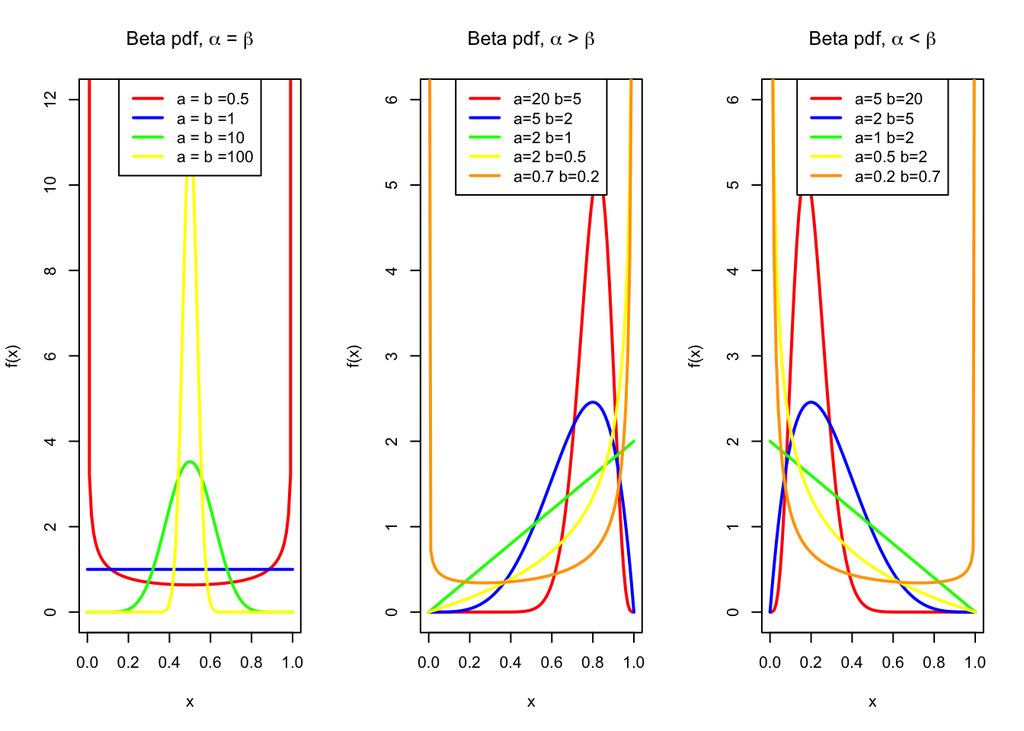

```r
cols <- c("red", "blue", "green", "yellow", "orange")
x <- seq(1e-6, 0.999999, length.out = 1000)

# f <- function(x, a, b){
#   exp(lgamma(a+b) - (lgamma(a) + lgamma(b)) + log(x)*(a-1) + log(1-x)*(b-1))
# }

par(mfrow = c(1, 3))

# (i) alpha = beta
alpha <- c(0.5, 1, 10, 100)
beta <- alpha
curve(dbeta(x, alpha[1], beta[1]), 1e-6, 999999e-6,
  col = cols[1], lwd = 2, ylim = c(0, 12),
  xlab = "x", ylab = "f(x)",
  main = expression(paste("Beta pdf, ", alpha, " = ", beta))
)
for (i in 2:4) curve(dbeta(x, alpha[i], beta[i]), add = TRUE, col = cols[i], lwd = 2)
legend("top", legend = paste0("a = b =", alpha), col = cols, lwd = 2)

# (ii) alpha > beta
ab <- list(c(20, 5), c(5, 2), c(2, 1), c(2, 0.5), c(0.7, 0.2))
curve(dbeta(x, ab[[1]][1], ab[[1]][2]), 1e-6, 999999e-6,
  col = cols[1], lwd = 2, ylim = c(0, 6),
  xlab = "x", ylab = "f(x)",
  main = expression(paste("Beta pdf, ", alpha, " > ", beta))
)
for (i in 2:5) curve(dbeta(x, ab[[i]][1], ab[[i]][2]), add = TRUE, col = cols[i], lwd = 2)
legend("top", legend = sapply(ab, function(p) paste0("a=", p[1], " b=", p[2])), col = cols, lwd = 2)

# (iii) alpha < beta
ab <- list(c(5, 20), c(2, 5), c(1, 2), c(0.5, 2), c(0.2, 0.7))
curve(dbeta(x, ab[[1]][1], ab[[1]][2]), 1e-6, 999999e-6,
  col = cols[1], lwd = 2, ylim = c(0, 6),
  xlab = "x", ylab = "f(x)",
  main = expression(paste("Beta pdf, ", alpha, " < ", beta))
)
for (i in 2:5) curve(dbeta(x, ab[[i]][1], ab[[i]][2]), add = TRUE, col = cols[i], lwd = 2)
legend("top", legend = sapply(ab, function(p) paste0("a=", p[1], " b=", p[2])), col = cols, lwd = 2)
```

##### Shape

- $\alpha$ controls the left edge, $\beta$ the right edge. Near 0, $f \approx x^{\alpha-1}$; near 1, $f \approx (1-x)^{\beta-1}$. If the parameter is below 1, the density blows up at that edge. At 1 it stays finite and nonzero. Above 1 it goes to 0.
- **Both below 1:** U-shaped, with mass piled at both ends.
- **Both equal to 1:** uniform.
- **Both above 1:** a single hump, with mode $\dfrac{\alpha-1}{\alpha+\beta-2}$.
- $\alpha = \beta$: symmetric about 0.5.
- $\alpha > \beta$: mass shifts toward 1.
- $\alpha < \beta$: mass shifts toward 0.

The ratio sets the mean:
$$E[Y] =
\frac{\alpha}{\alpha+\beta}$$

Doubling both $\alpha$ and $\beta$ leaves the mean unchanged. Only the balance between them moves the centre.

##### Spread

The total $\alpha+\beta$ sets the concentration:
$$\operatorname{Var}(Y) =
\frac{\mu(1-\mu)}{\alpha+\beta+1}, \qquad \mu =
\frac{\alpha}{\alpha+\beta}$$

For a fixed mean, a larger $\alpha+\beta$ gives a smaller variance. Small totals (0.5 + 0.5) give a spread-out, U-shaped density, and large totals (100 + 100) give a narrow, near-normal peak.

## FSDS - Chapter 3

### Ex 3.18 (Alessio Flego)

Sunshine City, which attracts primarily retired people, has 90,000 residents with a mean age of 72 years and a standard deviation of 12 years. The age distribution is skewed to the left. A random sample of 100 residents of Sunshine City has $\bar{y} = 70$ and $s = 11$.

1. Describe the center and spread of the (i) population distribution, (ii) sample data distribution. What shape does the sample data distribution probably have? Why?
2. Find the center and spread of the sampling distribution of $\bar{Y}$ for $n = 100$. What shape does it have and what does it describe?
3. Explain why it would not be unusual to sample a person of age 60 in Sunshine City, but it would be highly unusual for the sample mean to be 60, for a random sample of 100 residents.
4. Describe the sampling distribution of $\bar{Y}$: (i) for a random sample of size $n = 1$; (ii) if you sample all 90,000 residents.

**Solution**

#### (a)

1. The **population distribution** is the distribution of the ages of all $N = 90{,}000$ residents. Its center and spread are the parameters $\mu = 72$ and $\sigma = 12$ years.
2. The **sample data distribution** is the distribution of the ages of the $n = 100$ sampled residents. Its center and spread are the statistics $\bar{y} = 70$ and $s = 11$ years.

The sample data distribution is probably **skewed to the left** too: a random sample is representative of the population, so for a reasonably large $n$ the sample data distribution resembles the population distribution (and $\bar{y}$, $s$ are close to $\mu$, $\sigma$).

#### (b)

The sampling distribution of $\bar{Y}$ has
$$E(\bar{Y}) = \mu = 72, \qquad \sigma_{\bar{Y}} =
\frac{\sigma}{\sqrt{n}} = \frac{12}{\sqrt{100}} = 1.2$$

Since the population is finite, the exact standard error includes the finite population correction $\sqrt{(N-n)/(N-1)}$, but with $n/N \approx 0.001$ it is negligible:

```r
N <- 90000
mu <- 72
sigma <- 12
n <- 100

se <- sigma / sqrt(n)
fpc <- sqrt((N - n) / (N - 1))
c(se = se, se_fpc = se * fpc)
```

```
##      se  se_fpc
## 1.20000 1.19934
```

By the Central Limit Theorem, with $n = 100$ the sampling distribution is **approximately normal**, $\bar{Y} \sim N(72, 1.2^2)$, even though the population is skewed to the left. It describes how the sample mean $\bar{Y}$ would vary over all the possible random samples of 100 residents: about 95% of them would give $\bar{y}$ between $72 \pm 2(1.2)$, i.e. in $(69.6, 74.4)$.

#### (c)

For a single person the relevant spread is $\sigma = 12$, while for the sample mean it is $\sigma_{\bar{Y}} = 1.2$:
$$z_{\text{person}} = \frac{60 - 72}{12} = -1,
\qquad z_{\bar{Y}} = \frac{60 - 72}{1.2} = -10$$

```r
z_person <- (60 - mu) / sigma
z_mean <- (60 - mu) / se
c(z_person = z_person, z_mean = z_mean)
```

```
## z_person   z_mean
##       -1      -10
```

```r
pnorm(z_mean)
```

```
## [1] 7.619853e-24
```

An age of 60 is only one standard deviation below the population mean, so many residents are that age or younger. A sample mean of 60 instead lies 10 standard errors below $\mu$: its probability is practically 0. Individual ages vary a lot, but averaging 100 of them cancels most of this variability, so $\bar{Y}$ is very concentrated around $\mu = 72$.

#### (d)

1. With $n = 1$, $\bar{Y} = Y_1$ is just the age of one randomly chosen resident, so the sampling distribution of $\bar{Y}$ **is the population distribution**: mean 72, standard deviation $12/\sqrt{1} = 12$, skewed to the left.
2. If we sample all 90,000 residents, $\bar{Y}$ is always the population mean, so the sampling distribution is **degenerate at $\mu = 72$**, with standard error 0 (the finite population correction $\sqrt{(N-N)/(N-1)} = 0$).

#### Simulation

To illustrate, we build a left-skewed population of 90,000 ages with $\mu = 72$ and $\sigma = 12$ (100 times a beta variable, see Exercise 2.70), draw one sample of size 100 and then 10,000 samples to approximate the sampling distribution of $\bar{Y}$.

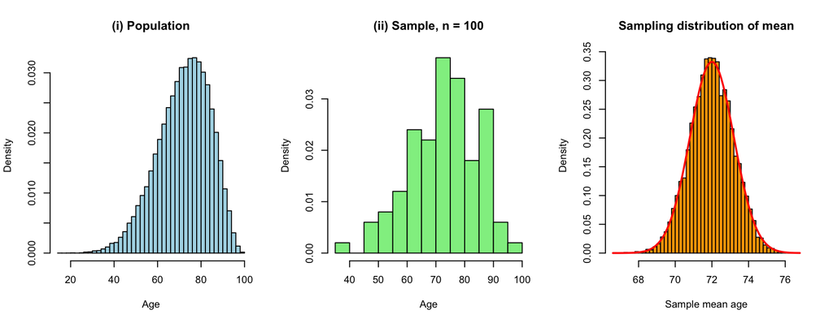

```r
set.seed(2026)

# left-skewed population on (0, 100): Y = 100 B, B ~ beta with mean 0.72 and variance 0.12^2,
# i.e. alpha + beta = m(1 - m) / v - 1 = 13, alpha = 0.72 * 13, beta = 0.28 * 13
m <- mu / 100
v <- (sigma / 100)^2
ab <- m * (1 - m) / v - 1
pop <- 100 * rbeta(N, m * ab, (1 - m) * ab)
pop <- mu + sigma * (pop - mean(pop)) / sd(pop) # exact mean 72 and sd 12

samp <- sample(pop, n)
ybar <- replicate(10000, mean(sample(pop, n)))

par(mfrow = c(1, 3))
hist(pop, breaks = 50, freq = FALSE, col = "lightblue", main = "(i) Population", xlab = "Age")
hist(samp, breaks = 15, freq = FALSE, col = "lightgreen", main = "(ii) Sample, n = 100", xlab = "Age")
hist(ybar,
  breaks = 50, freq = FALSE, col = "orange",
  main = "Sampling distribution of mean", xlab = "Sample mean age"
)
curve(dnorm(x, mu, se), add = TRUE, col = "red", lwd = 2)
```

```r
data.frame(
  Distribution = c("Population", "Sample", "Sampling dist. of Ybar"),
  Mean = round(c(mean(pop), mean(samp), mean(ybar)), 2),
  SD = round(c(sd(pop), sd(samp), sd(ybar)), 2)
)
```

```
##             Distribution  Mean    SD
## 1             Population 72.00 12.00
## 2                 Sample 72.79 11.87
## 3 Sampling dist. of Ybar 71.99  1.19
```

```r
# (c): proportion of residents aged 60 or less vs proportion of sample means <= 60
c(person = mean(pop <= 60), sample_mean = mean(ybar <= 60))
```

```
##      person sample_mean
##      0.1644      0.0000
```

```r
# (d): n = 1 gives back the population, n = N always gives mu
c(sd_n1 = sd(replicate(10000, mean(sample(pop, 1)))), mean_all = mean(sample(pop, N)))
```

```
##    sd_n1 mean_all
## 11.99745 72.00000
```

The sample histogram is left-skewed like the population, while the histogram of the 10,000 sample means is symmetric, bell-shaped and matches the $N(72, 1.2^2)$ curve. About 16% of the residents are 60 or younger, but none of the 10,000 sample means is that low.

### Ex 3.28 (Giovanni Norbedo)

A survey is planned to estimate the population proportion $\pi$ supporting more government action to address global warming. For a simple random sample, if $\pi$ may be near $0.50$, how large should $n$ be so that the standard error of the sample proportion $(\hat{\pi})$ is $0.04$?

**Solution**

The standard error formula for a sample proportion is:

$$SE(\hat{\pi}) = \sqrt{\frac{\pi(1 -
\pi)}{n}}$$

- Target Standard Error: $SE(\hat{\pi}) = 0.04$
- Estimated proportion: $\pi = 0.50$

$$\sqrt{\dfrac{0.50 (1 - 0.5)}{n}} =
\sqrt{\dfrac{1}{4n}} = 0.04$$

$$n = \dfrac{1}{4 \cdot 0.04^2} =
156.25$$

Since sample size must be a whole number of individuals:

$$n = \lceil 156.25 \rceil =
157$$

### Ex 3.24 (Giulio Ortoleva)

Construct a population distribution that is plausible for $Y = \text{number of alcoholic drinks in the past day}$.

- **(a)** Simulate a single random sample of size $n = 1000$ from this population to reflect results of a typical sample survey. Summarize how the sample mean and standard deviation resemble those for the population. *(Alternatively, you can do this and part (b) using an app, such as the Sampling Distribution for the Sample Mean (Discrete Population) app at www.artofstat.com/web-apps using the Build Custom Distribution option.)*
- **(b)** Now draw 10,000 random samples of size 1000 each, to approximate the sampling distribution of $\bar{Y}$. Report the mean and standard deviation of this simulated sampling distribution, and compare to the theoretical values. Explain what this sampling distribution represents.

#### Solution (a)

```r
my_seed <- 6632L
# each index represents the number of drinks consumed the past day
#        0    1     2    3      4     5    6      7
p <- c(0.15, 0.3, 0.22, 0.12, 0.08, 0.06, 0.05, 0.02)
y_values <- 0:(length(p) - 1)

stopifnot("must sum to 1" = sum(p) == 1)

# Theoretical population parameters
real_mean <- sum(y_values * p)
real_var <- sum((y_values - real_mean)^2 * p)
real_sd <- sqrt(real_var)

# ------------------------------------------------------------------------------
# Part (a): Single Random Sample (n = 1000)
# ------------------------------------------------------------------------------
set.seed(my_seed)
sample_size <- 1000
s <- sample(x = y_values, size = sample_size, replace = TRUE, prob = p)

sample_mean <- mean(s)
sample_sd <- sd(s)

sample_data <- c(sample_mean, sample_sd)
real_data <- c(real_mean, real_sd)
data.frame(
  Metric = c("Mean", "SD"),
  Sample = round(sample_data, 3),
  Real = round(real_data, 3),
  Difference = round(sample_data - real_data, 4)
)
```

```
##   Metric Sample  Real Difference
## 1   Mean  2.317 2.160     0.1570
## 2     SD  1.924 1.776     0.1481
```

*Giulio’s comment* In part (a) with a sample size of 1000, since I got a mu that was “very close” to the real mean, I just searched for a particular seed which resulted in a sample mean and sample variance as far from the real mean and the real variance as I could find. I came up with 6632, we see that despite the hand crafted seed, the sample mean (~2.3) seems to be very close to the real one (~2.16).

But if we measure the distance in terms of theoretical standard deviations:

```r
z_obs <- (sample_mean - real_mean) / (real_sd / sqrt(sample_size))
cat("z_obs:", z_obs)
```

```
## z_obs: 2.795383
```

We see that the sample mean is way far from being expected. We also can set a test hypothesis to answer the following: “If the real mean is 2.16, how much is the probability to observe a mean which is at least as rare as 2.317?” that is:
$$\begin{equation*}
\begin{cases}
h_0: \mu = 2.16\\
h_1: \mu \neq 2.16
\end{cases}
\end{equation*}$$
Calculating the p-value:

```r
p_val <- 2 * pnorm(abs(z_obs), lower.tail = FALSE)
cat("p-value:", p_val, "(", round(p_val * 100, 2), "%)")
```

```
## p-value: 0.005183831 ( 0.52 %)
```

Basically almost none, and this is expected because I selected a particuar anomalous seed.

#### Solution (b)

```r
# ------------------------------------------------------------------------------
# Part (b): Empirical Sampling Distribution (10,000 samples of sample_size = 1000)
# ------------------------------------------------------------------------------
num_samples <- 10000
set.seed(my_seed)

# Draw 10,000 sample means
sample_means <- replicate(
  num_samples,
  mean(
    sample(x = y_values, size = sample_size, replace = TRUE, prob = p)
  )
)

# Empirical parameters of the sampling distribution
sim_sampling_mean <- mean(sample_means)
sim_sampling_sd <- sd(sample_means)

# Theoretical parameters of the sampling distribution
theo_sampling_mean <- real_mean
theo_sampling_sd <- real_sd / sqrt(sample_size)

data.frame(
  Metric = c("Mean", "SD"),
  Simulated = round(c(sim_sampling_mean, sim_sampling_sd), 3),
  Theoretical = round(c(real_mean, theo_sampling_sd), 3),
  Difference = round(c(sim_sampling_mean, sim_sampling_sd) - c(real_mean, theo_sampling_sd), 3)
)
```

```
##   Metric Simulated Theoretical Difference
## 1   Mean     2.159       2.160     -0.001
## 2     SD     0.056       0.056      0.000
```

## FSDS - Chapter 4

### Ex 4.14 (Nicola Gigante)

Using the Students data file, for the corresponding population, construct a 95% confidence interval

1. for the mean weekly number of hours spent watching TV;
2. to compare females and males on the mean weekly number of hours spent watching TV.

In each case, state assumptions, including the practical importance of each, and interpret results.

**Solution**

We start loading the data.

```r
data <- read.table("http://stat4ds.rwth-aachen.de/data/Students.dat", header = TRUE)
head(data)
```

```
##   subject gender age hsgpa cogpa dhome dres tv sport news aids veg affil ideol
## 1       1      0  32   2.2   3.5     0  5.0  3     5    0    0   0     2     6
## 2       2      1  23   2.1   3.5  1200  0.3 15     7    5    6   1     1     2
## 3       3      1  27   3.3   3.0  1300  1.5  0     4    3    0   1     1     2
## 4       4      1  35   3.5   3.2  1500  8.0  5     5    6    3   0     3     4
## 5       5      0  23   3.1   3.5  1600 10.0  6     6    3    0   0     3     1
## 6       6      0  39   3.5   3.5   350  3.0  4     5    7    0   1     1     2
##   relig abor affirm life
## 1     2    0      0    1
## 2     1    1      1    3
## 3     2    1      1    3
## 4     1    1      1    2
## 5     0    1      0    2
## 6     1    1      1    3
```

#### (a)

In order to make a 95% CI for the mean of the population $\mu$ when $\sigma$ is not known, we use the Student’s t:
$$\bar{y} \pm t_{0.025,df} \cdot
\frac{s}{\sqrt{n}}$$

```r
CI_95 <- t.test(data$tv, conf.level = 0.95)
CI_95
```

```
##
##  One Sample t-test
##
## data:  data$tv
## t = 8.3794, df = 59, p-value = 1.252e-11
## alternative hypothesis: true mean is not equal to 0
## 95 percent confidence interval:
##  5.531395 9.001938
## sample estimates:
## mean of x
##  7.266667
```

So the sample mean is $\bar{Y}=7.266667$ and the CI is $[5.531395, 9.001938]$.

##### The fundamental assumptions for this interval are:

1. The 60 students must be a representative random sample of the target population. Id the sample is distorted, the inference cannot be generalised.
2. The TV hour distribution should be Normal. The one-sample t-test is very robust to deviations from normality when the sample size is not small (here $n = 60 \ge 30$), thanks to the CLT.

#### (b) compare females and males

We make now a 95% CI for the difference between the mean of the 2 grups ($\mu_{females} - \mu_{males}$) using `TV` and `gender` columns.

```r
CI_d95 <- t.test(data$tv ~ data$gender)
CI_d95
```

```
##
##  Welch Two Sample t-test
##
## data:  data$tv by data$gender
## t = -0.84995, df = 56.249, p-value = 0.399
## alternative hypothesis: true difference in means between group 0 and group 1 is not equal to 0
## 95 percent confidence interval:
##  -4.980854  2.013112
## sample estimates:
## mean in group 0 mean in group 1
##        6.500000        7.983871
```

##### The fundamental assumptions for this interval are:

1. The two groups (males and females) must be drawn from independent random samples. Practical significance: this is essential for the validity of the inference.
2. The variable `tv` should be normally distributed in both groups. Here too, the two-sample $t$-test is robust to non-normality thanks to the size of the two subsamples (around 30 per group). (Note: by using Welch’s test, we do not need to assume that the variances are equal, i.e. $\sigma_0^2 = \sigma_1^2$, which protects us from further errors).
- **Interpretation:** The 95% confidence interval for the difference in population means ($\mu_0 - \mu_1$, males minus females) is (-4.98, 2.01) hours. Since this interval contains $0$ (and the p-value is 0.399 $> 0.05$), we fail to reject $H_0: \mu_0 = \mu_1$. We conclude that there is no statistically significant difference between males and females in the mean weekly hours spent watching TV (males could watch up to ~5 hours less or up to ~2 hours more than females on average)

### Ex 4.16 (Fadhla Mohamed Mutua)

The Substance data file at the book’s website shows a contingency table formed from a survey that asked a sample of high school students whether they have ever used alcohol, cigarettes, and marijuana. Construct a 95% Wald confidence interval to compare those who have used or not used alcohol on whether they have used marijuana, using (a) formula (4.13); (b) software. State assumptions for your analysis, and interpret results.

**Solution**

Collapsing over cigarettes, the table is

| Alcohol | Marijuana yes | Marijuana no | Total |
| --- | --- | --- | --- |
| yes | 955 | 994 | 1949 |
| no | 5 | 322 | 327 |

##### Assumptions

- The students who have used alcohol and those who have not form two **independent binomial samples**, and each student’s response is independent of the others.
- The sample behaves like a random sample from the population of interest.
- The counts are large enough for the normal approximation. All cells are at least 5, but the 5 marijuana users among non-drinkers is borderline.
- Cigarette use is ignored by collapsing, which could confound the comparison.

##### (a) By hand

The Wald interval for $p_1 - p_2$ is
$$(\hat p_1 - \hat p_2) \pm
z_{1-\alpha/2}\sqrt{\frac{\hat p_1(1-\hat p_1)}{n_1} + \frac{\hat
p_2(1-\hat p_2)}{n_2}}$$

with
$$\begin{aligned}
\hat p_1 &= \frac{955}{1949} = 0.4900, \qquad \hat p_2 =
\frac{5}{327} = 0.0153, \qquad z_{0.975} = 1.96 \\[4pt]
SE &= \sqrt{\frac{0.4900(0.5100)}{1949} +
\frac{0.0153(0.9847)}{327}} = 0.0132 \\[4pt]
CI &= 0.4747 \pm 1.96(0.0132) = 0.4747 \pm 0.0259 \;\Rightarrow\;
(0.449,\ 0.501)
\end{aligned}$$

##### (b) Software

```r
substance <- read.table("http://stat4ds.rwth-aachen.de/data/Substance.dat", header = TRUE)

tab <- tapply(substance$count, list(substance$alcohol, substance$marijuana), sum)
tab
```

```
##      no yes
## no  322   5
## yes 994 955
```

```r
success <- tab[c("yes", "no"), "yes"]
total <- rowSums(tab)[c("yes", "no")]

p_hat <- success / total
d <- p_hat[1] - p_hat[2]
se <- sqrt(sum(p_hat * (1 - p_hat) / total))
d + c(-1, 1) * qnorm(0.975) * se
```

```
## [1] 0.4488310 0.5005777
```

```r
prop.test(success, total, correct = FALSE)$conf.int
```

```
## [1] 0.4488310 0.5005777
## attr(,"conf.level")
## [1] 0.95
```

##### Interpretation

We are 95% confident that the proportion who have used marijuana is between 0.449 and 0.501 higher among students who have used alcohol than among those who have not.

### Ex 4.48 (Alessio Flego)

For a simple random sample of $n$ subjects, explain why it is about 95% likely that the sample proportion has error no more than $1/\sqrt{n}$ in estimating the population proportion. (Hint: To show this “$1/\sqrt{n}$ rule,” find two standard errors when $\pi = 0.50$, and explain how this compares to two standard errors at other values of $\pi$.) Using this result, show that $n = 1/M^2$ is a safe sample size for estimating a proportion to within $M$ with 95% confidence.

**Solution**

#### The $1/\sqrt{n}$ rule

The sample proportion $\hat{\pi}$ has $E(\hat{\pi}) = \pi$ and standard error
$$\sigma_{\hat{\pi}} =
\sqrt{\frac{\pi(1-\pi)}{n}}$$
and for large $n$ its sampling distribution is approximately normal. Hence
$$P\left(|\hat{\pi} - \pi| \le
1.96\,\sigma_{\hat{\pi}}\right) \approx 0.95$$
so with probability about 0.95 the error is no more than about two standard errors.

When $\pi = 0.50$, two standard errors are
$$2\sqrt{\frac{0.50(0.50)}{n}} = 2
\cdot \frac{0.50}{\sqrt{n}} = \frac{1}{\sqrt{n}}$$

For any other $\pi$, two standard errors are smaller: $\pi(1-\pi)$ is a parabola with maximum at $\pi = 0.50$, since $\frac{d}{d\pi}\pi(1-\pi) = 1 - 2\pi = 0$ at $\pi = 0.50$, so $\pi(1-\pi) \le 0.25$ and
$$2\sigma_{\hat{\pi}} =
\frac{2\sqrt{\pi(1-\pi)}}{\sqrt{n}} \le \frac{1}{\sqrt{n}} \qquad
\text{for every } \pi$$

Therefore, whatever the value of $\pi$,
$$P\left(|\hat{\pi} - \pi| \le
\frac{1}{\sqrt{n}}\right) \ge P\left(|\hat{\pi} - \pi| \le
2\sigma_{\hat{\pi}}\right) \approx 0.95$$
with “about 95%” at $\pi = 0.50$ and even more for $\pi$ far from 0.50.

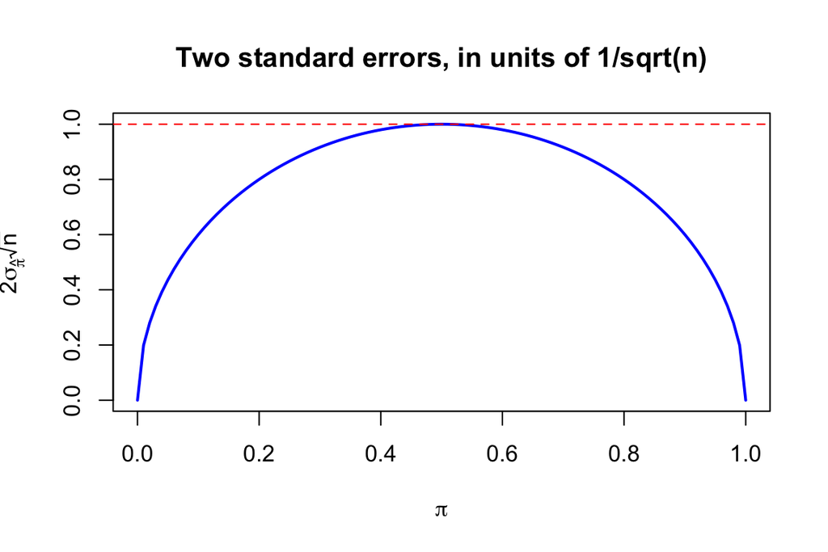

```r
pi_grid <- seq(0, 1, by = 0.01)
plot(pi_grid, 2 * sqrt(pi_grid * (1 - pi_grid)),
  type = "l", lwd = 2, col = "blue",
  xlab = expression(pi), ylab = expression(2 * sigma[hat(pi)] * sqrt(n)),
  main = "Two standard errors, in units of 1/sqrt(n)"
)
abline(h = 1, col = "red", lty = 2)
```

The curve $2\sqrt{\pi(1-\pi)}$ touches the bound 1 only at $\pi = 0.50$. We check the rule by simulation, with $n = 400$ (so $1/\sqrt{n} = 0.05$):

```r
set.seed(1)
n <- 400
B <- 10000
pis <- c(0.05, 0.1, 0.3, 0.5, 0.7, 0.9)

# proportion of samples with |pi_hat - pi| <= 1/sqrt(n)
P_rule <- sapply(pis, function(p) mean(abs(rbinom(B, n, p) / n - p) <= 1 / sqrt(n)))

data.frame(
  pi = pis,
  two_se = round(2 * sqrt(pis * (1 - pis) / n), 4),
  bound = 1 / sqrt(n),
  P_error_le_bound = P_rule
)
```

```
##     pi two_se bound P_error_le_bound
## 1 0.05 0.0218  0.05           1.0000
## 2 0.10 0.0300  0.05           0.9994
## 3 0.30 0.0458  0.05           0.9753
## 4 0.50 0.0500  0.05           0.9557
## 5 0.70 0.0458  0.05           0.9734
## 6 0.90 0.0300  0.05           0.9987
```

#### Sample size $n = 1/M^2$

We want the error to be at most $M$ with 95% confidence. From the rule, the error is at most $1/\sqrt{n}$ with probability at least about 0.95, so it is enough to set
$$\frac{1}{\sqrt{n}} = M \quad\Rightarrow\quad
\boxed{n = \frac{1}{M^2}}$$

This is a **safe** sample size because it is computed in the worst case $\pi = 0.50$, so we do not need to guess $\pi$: for any other $\pi$ the margin of error is smaller than $M$. Compared with the formula $n = z_{0.025}^2\,\pi(1-\pi)/M^2$ with $\pi = 0.50$, it uses $2$ instead of $1.96$, so it is slightly conservative:

```r
M <- c(0.05, 0.03, 0.01)
data.frame(
  M = M,
  n_rule = 1 / M^2,
  n_exact = ceiling(qnorm(0.975)^2 * 0.25 / M^2)
)
```

```
##      M    n_rule n_exact
## 1 0.05   400.000     385
## 2 0.03  1111.111    1068
## 3 0.01 10000.000    9604
```

For example, to estimate a proportion to within $M = 0.03$ it is safe to sample about $n = 1/0.03^2 \approx 1112$ subjects.

## FSDS - Chapter 5

### Ex 5.2 (Giovanni Norbedo)

When a government does not have enough money to pay for the services that it provides, it can raise taxes or it can reduce services. When the Florida Poll asked a random sample of 1200 Floridians which they preferred, 52% (624 of the 1200) chose *raise taxes* and 48% chose reduce services.

Let $\pi$ denote the population proportion of Floridians who would choose raising taxes. Analyze whether this is a minority of the population ($\pi < 0.50$) or a majority ($\pi > 0.50$) by testing $H_0: \pi = 0.50$ against $H_a: \pi \neq 0.50$. Interpret the $P$-value. Is it appropriate to “accept $H_0$? Why or why not?

**Solution**

$n = 1200 \quad X = 624 \quad \hat{\pi} = 0.52$

Test:

$$\begin{align*}
H_0 &: \pi = 0.50 \\
H_a &: \pi \neq 0.50
\end{align*}$$

Under the null hypothesis, the standard error is calculated as:

$$\text{SE}_0(\hat{\pi}) =
\sqrt{\frac{0.50 \times 0.50}{1200}} \approx 0.01443$$

This gives a Wald test statistic of:

$$Z = \frac{0.52 - 0.50}{0.01443} \approx
1.386$$

The corresponding two-sided p-value is $2 \times P(Z \ge 1.386) \approx 0.166$. Because $p = 0.166 > 0.05$, there is insufficient statistical evidence to reject $H_0$. The observed 52% preference can be naturally accounted for by random sampling variation.

We avoid stating that we “accept” $H_0$ because a non-significant result merely shows that the observed data are compatible with the null hypothesis, not that $\pi = 0.50$ is proven true. Frequentist hypothesis tests control for Type I errors rather than proving null parameters, so a high p-value might simply reflect limited power to detect small deviations.

### Ex 5.12 (Giulio Ortoleva)

The example in Section 3.1.4 described an experiment to estimate the mean sales with a proposed menu for a new restaurant.

In a revised experiment to compare two menus, on Tuesday of the opening week the owner gives customers menu A and on Wednesday she gives them menu B.

The bills average $22.30 for the 43 customers on Tuesday ($s_A = 6.88$) and $25.91 for the 50 customers on Wednesday ($s_B = 8.01$).

Under the strong assumption that her customers each night are comparable to a random sample from the conceptual population of potential customers, show how to compare the mean sales for the two menus based on:

**(a)** The $P$-value of a significance test.

**(b)** A 95% confidence interval.

Which is more informative, and why?

*(When used in an experiment to compare two treatments to determine which works better, a two-sample test is often called an A/B test.)*

**Data setup**

```r
menu_a <- data.frame(
  day  = "tuesday",
  n    = 43,
  mean = 22.30,
  s    = 6.88
)

menu_b <- data.frame(
  day  = "wednesday",
  n    = 50,
  mean = 25.91,
  s    = 8.01
)

ab_test <- data.frame(
  sample_mean = menu_b$mean - menu_a$mean,
  s           = sqrt((menu_a$s^2 / menu_a$n) + (menu_b$s^2 / menu_b$n)),
  t_obs       = NA_real_,
  p_value     = NA_real_
)
ab_test
```

```
##   sample_mean        s t_obs p_value
## 1        3.61 1.544021    NA      NA
```

For A/B testing we need to build the new random variable:
$$\bar{C} = \bar{X} - \bar{Y}$$
The mean is calculated as:
$$E(\bar{X} - \bar{Y}) =
E(\bar{X}) - E(\bar{Y}) \approx \bar{x} - \bar{y}$$
Assuming $\bar{X}$ and $\bar{Y}$ as indipendent ($Cov(\bar{X},\bar{Y}) = 0$) we can compute the variance of the new rv as:
$$Var(\bar{X}
- \bar{Y}) = Var(\bar{X}) + Var(\bar{Y})$$
Which for observed means with size $n_x$ and $n_y$ using the Welch approach:
$$Var(\bar{X}) + Var(\bar{Y}) \approx
\frac{1}{n_x}\sum_i (x_i - \bar{x})^2 + \frac{1}{n_y}\sum_i (y_i -
\bar{y})^2$$

#### Solution (a)

- The p-value answers the following question: “How is likely that those two sample means are at least that different?”
- Where “that different” refers to the value of $\bar{C}$ by construction.

*Letters legend:*

- t: tuesday (menu_a)
- w: wednesday (menu_b)

$$\begin{equation*}
\begin{cases}
h_0: \mu_w - \mu_t = 0\\
h_1: \mu_w - \mu_t \neq 0
\end{cases}
\end{equation*}$$

We can now compute the t-test statistic:

```r
ab_test$t_obs <- (ab_test$sample_mean) / ab_test$s
cat("t_obs:", ab_test$t_obs)
```

```
## t_obs: 2.338051
```

The p_value:

```r
ab_test$p_value <- pnorm(ab_test$t_obs, lower.tail = FALSE) * 2
cat("p_value:", ab_test$p_value, "< alpha=0.05 :", ab_test$p_value < 0.05)
```

```
## p_value: 0.01938463 < alpha=0.05 : TRUE
```

With a significance level $\alpha = 0.05$ we would reject the null hypothesis, so the menus are actually statistically different.

#### Solution (b)

- The confidence interval is calculated as follows:
  $$lower, upper = \bar{c} \pm z_{\alpha/2}
  s_c$$

```r
IC <- data.frame(
  SE     = NA_real_,
  upper  = NA_real_,
  mean   = ab_test$sample_mean,
  lower  = NA_real_,
  z_crit = NA_real_
)
```

We first fix an alpha, which for 95% confidence is 0.05, then can compute $z_{\alpha/2}$, then we can compute upper and lower since we have all the terms:

```r
alpha <- 0.05
IC$z_crit <- abs(qnorm(alpha / 2))
IC$SE <- round(ab_test$s, 3)
IC$upper <- round(IC$mean + IC$z_crit * ab_test$s, 3)
IC$lower <- round(IC$mean - IC$z_crit * ab_test$s, 3)
IC
```

```
##      SE upper mean lower   z_crit
## 1 1.544 6.636 3.61 0.584 1.959964
```

**Final Answer**: The confidence interval is more informative because it states, with a confidence of 95%, the interval of values in which the real difference could actually be (from a bayesian point of view). So in this case for example we can say not only that the two menus are different, but with a good level of confidence also that it differs at least of a delta=$0.584, so the menu B is very likely to be more profitable at least per person.

### Ex 5.50 (Nicola Gigante)

A random sample of size $40$ has $\bar{y} = 120$. The P-value for testing $H_0: \mu = 100$ against $H_a: \mu \neq 100$ is $0.057$. Explain what is incorrect about each of the following interpretations of this P-value, and provide a proper interpretation.

1. The probability that $H_0$ is correct equals $0.057$.
2. The probability that $\bar{y} = 120$ if $H_0$ is true equals $0.057$.
3. The probability of Type I error equals $0.057$.
4. We can accept $H_0$ at the $\alpha = 0.05$ level.

**Solution**

- **(a) Incorrect:** In classical (frequentist) inference, the population parameter $\mu$ is fixed, not a random variable, so $H_0$ is either true (probability $1$) or false (probability $0$). The P-value is the probability of observing extreme data given that $H_0$ is true, $P(\text{extreme data} \mid H_0)$, not the probability that $H_0$ is true given the data, $P(H_0 \mid \text{data})$.
- **(b) Incorrect:** For a continuous sampling distribution, the probability of observing the exact value $\bar{y} = 120$ is $0$. The P-value refers to the probability of observing a sample mean **at least as extreme as** $120$ in either tail (i.e., $\bar{Y} \ge 120$ or $\bar{Y} \le 80$).
- **(c) Incorrect:** The probability of a Type I error is the preset significance level $\alpha$ (e.g., $\alpha = 0.05$), not the P-value, which varies from sample to sample. Moreover, if we do not reject $H_0$ (since $0.057 > 0.05$), we cannot commit a Type I error at all—we only risk committing a **Type II error**.
- **(d) Incorrect:** When the P-value is greater than $\alpha = 0.05$, we **fail to reject** $H_0$ rather than “accepting” it. Failing to find sufficient evidence against $\mu = 100$ does not prove that $\mu$ is equal to $100$; many other values around $100$ are also plausible.
- **Proper Interpretation:** Assuming that the null hypothesis $H_0: \mu = 100$ is true, the probability of obtaining a sample mean $\bar{Y}$ at least $20$ units away from $100$ in either direction (that is, $\bar{Y} \ge 120$ or $\bar{Y} \le 80$) in a random sample of size $40$ is $0.057$.

## CS - Chapter 1

### Ex 1.1 (Fadhla Mohamed Mutua)

An exponential random variable $X \ge 0$ has p.d.f. $f(x) = \lambda e^{-\lambda x}$, with $\lambda > 0$.

1. Find the c.d.f. and the quantile function of $X$.
2. Find $P(X \le \lambda)$ and the median of $X$.
3. Find the mean and variance of $X$.

**Solution**

#### (1)

The c.d.f. is obtained by integrating up to $x$. Since $\dfrac{d}{dt}\left(-e^{-\lambda t}\right) = \lambda e^{-\lambda t}$,
$$F(x) =
\int_0^x \lambda e^{-\lambda t}\,dt = \Big[-e^{-\lambda t}\Big]_0^x =
\boxed{1 - e^{-\lambda x}}, \qquad x \ge 0$$

A check that $f$ is a valid density:
$$\int_0^\infty \lambda e^{-\lambda
x}\,dx = \Big[-e^{-\lambda x}\Big]_0^\infty = 0 + 1 = 1$$

The quantile function solves $F(x) = p$ for $x$, with $p \in (0,1)$:
$$\begin{aligned}
1 - e^{-\lambda x} &= p \\
e^{-\lambda x} &= 1 - p \\
-\lambda x &= \ln(1 - p) \\
x &= -\frac{\ln(1-p)}{\lambda}
\end{aligned}
\qquad\Rightarrow\qquad \boxed{Q(p) =
-\frac{\ln(1-p)}{\lambda}}$$

#### (2)

Substituting $x = \lambda$ in the c.d.f.,
$$P(X \le \lambda) = F(\lambda) = 1 -
e^{-\lambda \cdot \lambda} = \boxed{1 - e^{-\lambda^2}}$$

The median is the $0.5$ quantile:
$$Q(0.5) = -\frac{\ln(0.5)}{\lambda} =
\boxed{\frac{\ln 2}{\lambda}}$$

#### (3)

**Mean.** $E[X] = \displaystyle\int_0^\infty x\,\lambda e^{-\lambda x}\,dx$. Integrate by parts with $u = x$ and $dv = \lambda e^{-\lambda x}dx$, so $du = dx$ and $v = -e^{-\lambda x}$:
$$\begin{aligned}
E[X] &= \Big[-x e^{-\lambda x}\Big]_0^\infty + \int_0^\infty
e^{-\lambda x}\,dx \\
&= 0 + \frac{1}{\lambda}\int_0^\infty \lambda e^{-\lambda x}\,dx \\
&= \boxed{\frac{1}{\lambda}}
\end{aligned}$$
The boundary term vanishes because $x e^{-\lambda x} \to 0$ as $x \to \infty$ (exponential decay beats linear growth).

**Second moment.** $E[X^2] = \displaystyle\int_0^\infty x^2\,\lambda e^{-\lambda x}\,dx$. Integrate by parts with $u = x^2$ and $dv = \lambda e^{-\lambda x}dx$:
$$\begin{aligned}
E[X^2] &= \Big[-x^2 e^{-\lambda x}\Big]_0^\infty + \int_0^\infty
2x\,e^{-\lambda x}\,dx \\
&= 0 + \frac{2}{\lambda}\int_0^\infty x\,\lambda e^{-\lambda x}\,dx
\\
&= \frac{2}{\lambda}\,E[X] = \boxed{\frac{2}{\lambda^2}}
\end{aligned}$$

**Variance.**
$$V(X) = E[X^2]
- (E[X])^2 = \frac{2}{\lambda^2} - \frac{1}{\lambda^2} =
\boxed{\frac{1}{\lambda^2}}$$

### Ex 1.6 (Alessio Flego)

Let $X$ and $Y$ be non-independent random variables, such that $\text{var}(X) = \sigma_x^2$, $\text{var}(Y) = \sigma_y^2$ and $\text{cov}(X, Y) = \sigma_{xy}^2$. Using the result from Section 1.6.2, find $\text{var}(X + Y)$ and $\text{var}(X - Y)$.

**Solution**

Let $\mathbf{X} = (X, Y)^\mathsf{T}$, with mean vector $\boldsymbol{\mu}$ and covariance matrix
$$\boldsymbol{\Sigma} = \begin{bmatrix}
\sigma_x^2 & \sigma_{xy}^2 \\ \sigma_{xy}^2 & \sigma_y^2
\end{bmatrix}$$

Section 1.6.2 states that, if $\mathbf{a}$ is a vector of finite real constants, then $\mathbf{a}^\mathsf{T}\mathbf{X} \sim N(\mathbf{a}^\mathsf{T}\boldsymbol{\mu}, \mathbf{a}^\mathsf{T}\boldsymbol{\Sigma}\mathbf{a})$. The variance part of this result does not require normality, since it only uses the linearity of expectation:
$$\text{var}(\mathbf{a}^\mathsf{T}\mathbf{X}) =
E\left[\{\mathbf{a}^\mathsf{T}(\mathbf{X} - \boldsymbol{\mu})\}^2\right]
= E\left[\mathbf{a}^\mathsf{T}(\mathbf{X} - \boldsymbol{\mu})(\mathbf{X}
- \boldsymbol{\mu})^\mathsf{T}\mathbf{a}\right] =
\mathbf{a}^\mathsf{T}\boldsymbol{\Sigma}\mathbf{a}$$

**Sum.** $X + Y = \mathbf{a}^\mathsf{T}\mathbf{X}$ with $\mathbf{a} = (1, 1)^\mathsf{T}$:
$$\text{var}(X + Y) = \begin{bmatrix} 1 & 1
\end{bmatrix}
\begin{bmatrix} \sigma_x^2 & \sigma_{xy}^2 \\ \sigma_{xy}^2 &
\sigma_y^2 \end{bmatrix}
\begin{bmatrix} 1 \\ 1 \end{bmatrix}
= \begin{bmatrix} \sigma_x^2 + \sigma_{xy}^2 & \sigma_{xy}^2 +
\sigma_y^2 \end{bmatrix}
\begin{bmatrix} 1 \\ 1 \end{bmatrix}
= \boxed{\sigma_x^2 + \sigma_y^2 + 2\sigma_{xy}^2}$$

**Difference.** $X - Y = \mathbf{a}^\mathsf{T}\mathbf{X}$ with $\mathbf{a} = (1, -1)^\mathsf{T}$:
$$\text{var}(X - Y) = \begin{bmatrix} 1 & -1
\end{bmatrix}
\begin{bmatrix} \sigma_x^2 & \sigma_{xy}^2 \\ \sigma_{xy}^2 &
\sigma_y^2 \end{bmatrix}
\begin{bmatrix} 1 \\ -1 \end{bmatrix}
= \begin{bmatrix} \sigma_x^2 - \sigma_{xy}^2 & \sigma_{xy}^2 -
\sigma_y^2 \end{bmatrix}
\begin{bmatrix} 1 \\ -1 \end{bmatrix}
= \boxed{\sigma_x^2 + \sigma_y^2 - 2\sigma_{xy}^2}$$

Both results can be obtained at once with the matrix $\mathbf{A} = \begin{bmatrix} 1 & 1 \\ 1 & -1 \end{bmatrix}$, since $\mathbf{A}\mathbf{X} = (X + Y, X - Y)^\mathsf{T}$ has covariance matrix
$$\mathbf{A}\boldsymbol{\Sigma}\mathbf{A}^\mathsf{T}
= \begin{bmatrix} \sigma_x^2 + \sigma_y^2 + 2\sigma_{xy}^2 &
\sigma_x^2 - \sigma_y^2 \\ \sigma_x^2 - \sigma_y^2 & \sigma_x^2 +
\sigma_y^2 - 2\sigma_{xy}^2 \end{bmatrix}$$
whose diagonal gives the two variances (and the off-diagonal term shows that $\text{cov}(X + Y, X - Y) = \sigma_x^2 - \sigma_y^2$).

Since $X$ and $Y$ are not independent, $\sigma_{xy}^2 \ne 0$ in general: a positive covariance increases the variance of the sum and decreases that of the difference, and vice versa. Only when $\sigma_{xy}^2 = 0$ (e.g. under independence) do both reduce to $\sigma_x^2 + \sigma_y^2$.

We check the result numerically, generating $(X, Y)^\mathsf{T}$ as in the definition of Section 1.6, $\mathbf{X} = \mathbf{B}\mathbf{Z}$ with $\mathbf{Z}$ i.i.d. $N(0, 1)$ and $\mathbf{B}\mathbf{B}^\mathsf{T} = \boldsymbol{\Sigma}$ (from the Cholesky factor), with $\sigma_x^2 = 4$, $\sigma_y^2 = 9$, $\sigma_{xy}^2 = 1.5$:

```r
set.seed(3)
Sigma <- matrix(c(4, 1.5, 1.5, 9), 2, 2)
B <- t(chol(Sigma)) # chol() returns R with t(R) %*% R = Sigma, so B %*% t(B) = Sigma
Z <- matrix(rnorm(2 * 1e6), 2) # each column is a vector of 2 i.i.d. N(0, 1)
XY <- B %*% Z # each column is a draw of (X, Y)^T

A <- matrix(c(1, 1, 1, -1), 2, 2, byrow = TRUE)
A %*% Sigma %*% t(A) # theoretical covariance matrix of (X + Y, X - Y)
```

```
##      [,1] [,2]
## [1,]   16   -5
## [2,]   -5   10
```

```r
round(cov(t(A %*% XY)), 3) # simulated covariance matrix of (X + Y, X - Y)
```

```
##        [,1]   [,2]
## [1,] 16.039 -5.018
## [2,] -5.018 10.003
```

The simulated variances agree with $\text{var}(X + Y) = 4 + 9 + 2(1.5) = 16$ and $\text{var}(X - Y) = 4 + 9 - 2(1.5) = 10$.

## CS - Chapter 3

### Ex 3.5 (Giovanni Norbedo)

Consider solving the matrix equation $Ax = y$ for $x$, where $y$ is a known $n$-vector and $A$ is a known $n \times n$ matrix. The formal solution to the problem is $x = A^{-1}y$, but it is possible to solve the equation directly, without actually forming $A^{-1}$.

1. First create an $A$, $x$ and $y$ satisfying $Ax = y$.
2. Using `solve`, form the matrix $A^{-1}$ explicitly and then form $x_1 = A^{-1}y$. Note how long this takes and assess the mean absolute error.
3. Now use `solve` to directly solve for $x$ without forming $A^{-1}$. Note how long this takes and assess the mean absolute error.
4. What do you conclude?

**Solution**

```r
set.seed(0)
n <- 1000
A <- matrix(runif(n * n), n, n)
x.true <- runif(n)
y <- A %*% x.true

t1 <- system.time({
  A_inv <- solve(A)
  x1 <- A_inv %*% y
})
mae1 <- mean(abs(x1 - x.true))

t2 <- system.time({
  x2 <- solve(A, y)
})
mae2 <- mean(abs(x2 - x.true))

cat("Explicit inverse : Time =", t1["elapsed"], "s , MAE =", mae1, "\n")
```

```
## Explicit inverse : Time = 0.052 s , MAE = 2.880889e-11
```

```r
cat("Direct solution  : Time =", t2["elapsed"], "s , MAE =", mae2, "\n")
```

```
## Direct solution  : Time = 0.016 s , MAE = 1.699024e-12
```

Directly solving the linear system using `solve(A, y)` is strongly preferred: it is significantly faster and numerically more accurate (having a lower mean absolute error) than explicitly inverting the matrix via `solve(A) %*% y`.

### Ex 3.6 (Giulio Ortoleva)

The empirical cumulative distribution function for a set of measurements $\{x_i : i = 1, \dots, n\}$ is
$$\hat{F}(x) = \frac{\#\{x_i
< x\}}{n}$$
where $\#\{x_i < x\}$ denotes ‘number of $x_i$ values less than $x$’. When answering the following, try to ensure that your code is commented, clearly structured, and tested. To test your code, generate random samples using `rnorm`, `runif`, etc.

1. Write an R function that takes an unordered vector of observations `x` and returns the values of the empirical c.d.f. for each value, in the order corresponding to the original `x` vector. See `?sort.int`.
2. Modify your function to take an extra argument `plot.cdf`, that when `TRUE` will cause the empirical c.d.f. to be plotted as a step function over a suitable $x$ range.

#### Solution

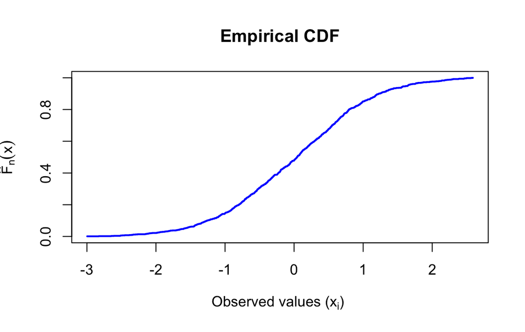

```r
library(latex2exp)

set.seed(7)

#' Return the cumulated function distribution values for each number
#' inside x mantaining the input order (stability).
#'
#' @param x A numeric vector.
#' @return A numeric vector.
#' @export
my_cdf <- function(x, plot = FALSE) {
  sx <- sort.int(x)
  cdf_vals <- findInterval(x, sx) / length(x)
  if (plot) {
    plot(sx, sort.int(cdf_vals),
      ylim = range(0, 1),
      main = "Empirical CDF",
      xlab = TeX(r'(Observed values ($x_i$) )'),
      ylab = TeX(r'($\hat{F}_n(x)$)'),
      col = "blue",
      lwd = 2,
      type = "s"
    )
  }
  cdf_vals
}

x <- rnorm(100000, mean = 0, sd = 1)
stopifnot(
  "my_cdf vs R cdf must return the same result" = (
    isTRUE(all.equal(my_cdf(x), ecdf(x)(x)))
  )
)
n <- 1000
vals <- my_cdf(rnorm(n, mean = 0, sd = 1), plot = TRUE)
```

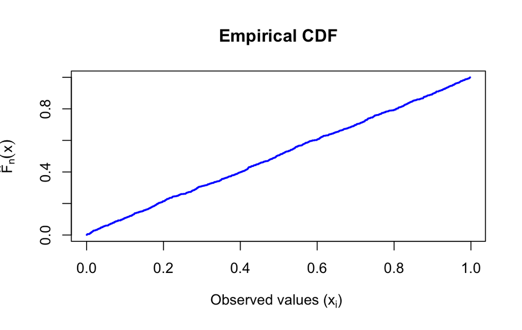

```r
vals <- my_cdf(runif(n), plot = TRUE)
```

*Giulio’s comments*:

`findInterval` is vectorialized and will find the length of the interval inside the sorted observation `sx` for every value of the original non sorted value of the observed data.

Then to compare floating results from the cdf `all.equal` is needed because of possible floating error.